# Lesson4

## **Probability and distributions**

### **Random Process**

In a *Random Process* we know what outcomes could happen, but we don´t know which particular outcome will happen.

### **Probability**

*Notation*: P(A) = Probability of event A

*Rule*: 0 <= P(A) <= 1

*Definition*:

- *Frequentist Interpretation*: The probability of an outcome is the proportion of times the outcome would occur if we observed the random process and infinite number of times.
- *Bayesian Interpretation*: A bayesian interprets probability as a subjective degree of belief. Popular in the late twenty years.

### **Law of large numbers**

*Law of large numbers* states that as more observations are collected (more random process), the proportion of occurrences with a particular outcome converges to the probability of that outcome

*for example, we expect the Proportion of 5´s in a dice to set down to 1/6 with increasing number of rolls*

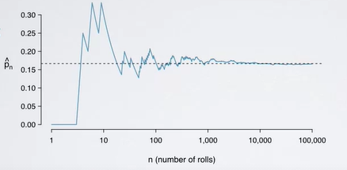

*Coin is memoryless*: The probability of heads on the 11th toss is the same as the probability of heads in the 10th toss, or any previous tosses P(Head on the 11th toss) = P(Head on the 11th toss) = 0.5

*Gambler´s fallacy/law of averages*: Random processes are supposed to compensate for whatever happened in the past…. no, common misunderstanding of the law of large numbers

## **Disjoint Events + General Addition Rule**

### **Disjoint Events**

*Disjoint Events* (Mutually exclusive) cannot happen at the same time.  
* A student can´t both fail and pass a class  
* A singe card drawn from a deck cannot be an ace and a queen

*In Venn diagram, where we represent each event by circles, if A and B are disjoint we end up with two circles that don´t touch each other*

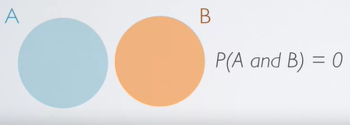

### **Non Disjoint Events**

*Non-Disjoint Events* Can happen at the same time  
* A student can get an A in Stats and A in Econ in the same semester

*In Venn diagram,if A and B are non- disjoint we end up with two circles that join*

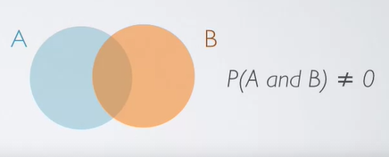

### **Union of Disjoint Events**

*Union: Probability of one event or the other happening*

[figure not shown]

### **Union of Non-Disjoint Events**

*We need to consider the join part of the two events in order to not double count and inflate our probability of a desire outcome*

[figure not shown]

### **General addition rule**

P(A or B) = P(A) + P(B) - P(A and B)

and when the events are disjoint (P(A and B) = 0)..

P(A or B) = P(A) + P(B)

### **Sample space**

A *Sample space* is a collection of all possible outcomes of a trial

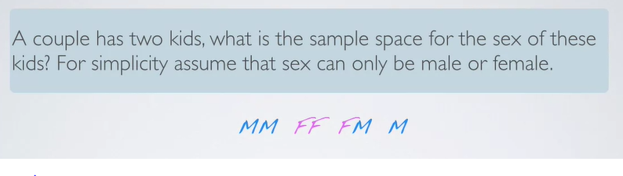

### **Probability distribution**

A *Probability distribution* lists all possible outcomes in the sample space, and the probabilities with which thee occur

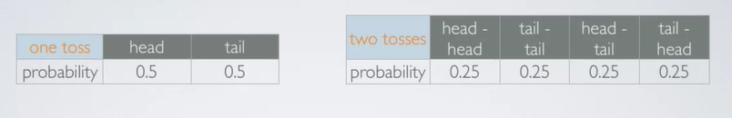

**Rules** * The events listed must be disjoint * Each probability must be between 0 and 1 * The probability must total 1 (the sum)

### **Complementary events**

*Complementary events* are two mutually exclusive (disjoint) events whose probabilities add up to 1

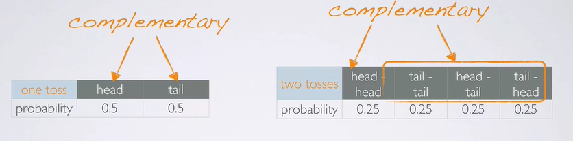

### **Disjoint vs. complementary**

Do the sum probabilities of two disjoint outcomes always add up to 1?

**No** there may be more than 2 outcomes in the sample space

## **Independence**

Two processes are *Independent* if knowing the outcome of one provides no useful information about the outcome of the other

- Outcomes of two tosses of a coin are *independent*
- Outcomes of two draws form a deck of cars (without replacement) are *dependent*

### **Checking for independence**

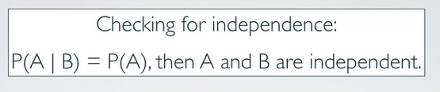

### **Example**

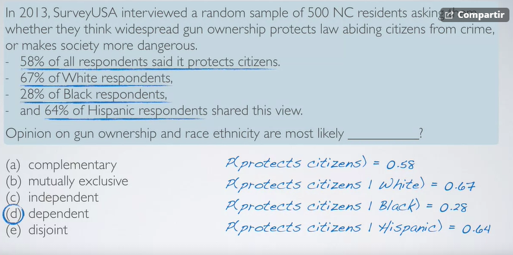

we use the expression **Most likely dependent** because we are dealing with sample data

If we observed difference between conditional probabilities (based in the sample) –> most likely dependent —> Hypothesis test to see if this difference is not due to chance

### **Rules with independent events**

- **Product rule**

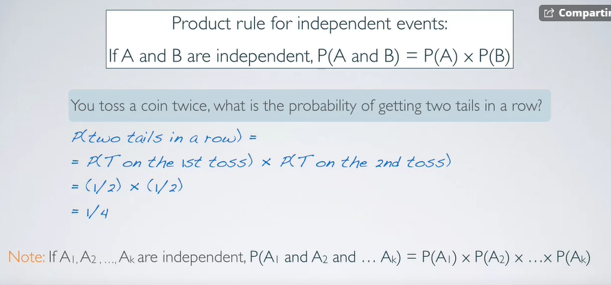

**Important Note** random selection implies independence

## —————————————————————————————————-

*Observation*: We can see a similarity between a dice roll and a sample

dice roll – we know the 6 options and their relative frequencies (each option repeat only one time) — if we roll the dice many times we get to the original relative frequencies.  
The 6 options and their relative frequencies is like a population that we don´t know – if we take a sample of it we can get to the relative frequencies of the population  
————————————————————————————————————————————————————————————

## **Disjoint vs. Independent**

Disjointness is about events happening at the same time. While independence os about processes not affecting each other.

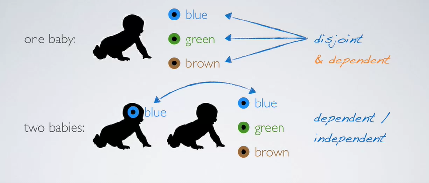

**Note**: Disjoint events with non zero probability are always dependent on each other.Because if we know that one happened, we know that the other one cannot happen